# Module R: Repetition

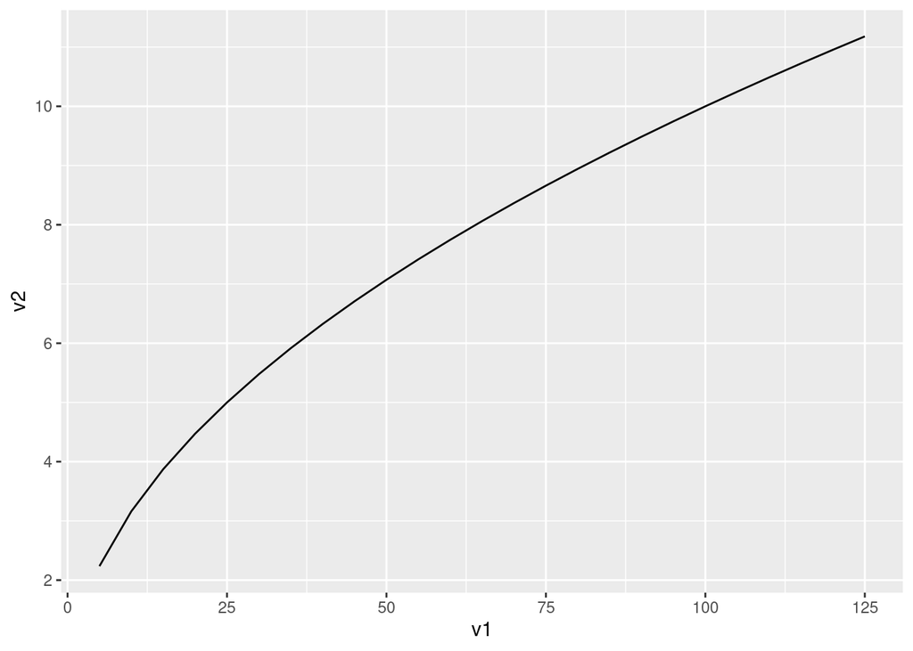

```r
ggplot(data.frame(v1,v2), aes(x=v1, y=v2)) + geom_line()
```

**Exercise**

.. (no exercise text provided, see solution for inspiration)

**Solution**

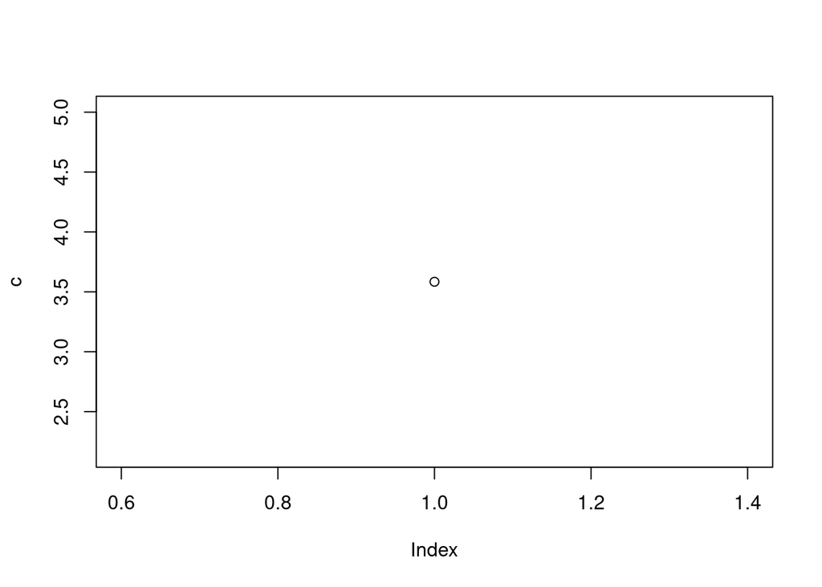

```r
library(tidyverse)
c <- log10(2)+log10(4)+log10(6)+log10(8)+log10(10)
d <- seq(1:5)*(3/4)
plot(c)
```

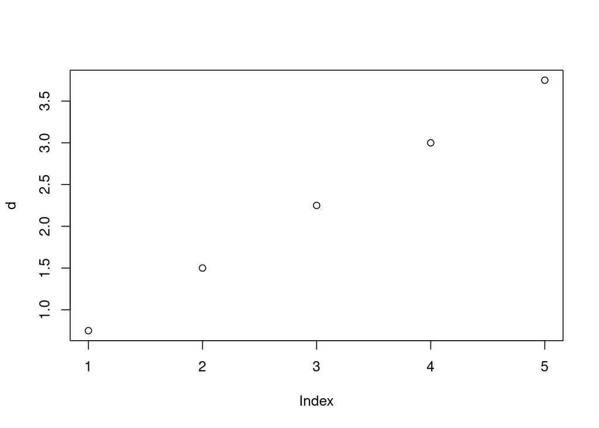

```r
plot(d)
```

```r
length(c)
```

```
[1] 1
```

```r
length(d)
```

```
[1] 5
```

**Exercise**

Explain what the `rm(list = ls())` call does.

**Solution**

ls() inside rm(). The rm() stands for remove, and ls() stands for list. We combine them in the following way to make R ‘clear’ its brain.

**Exercise**

Creating a vector from 0 to 200 with stepsize 4, save it as a, create a second vector as the power of 3 plus 1 of vector a. Plot it.

**Solution**

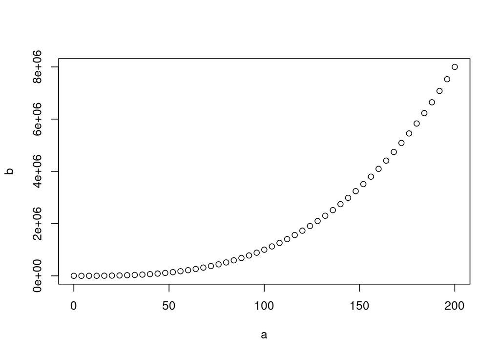

```r
a <- seq(from = 0, to = 200, by = 4)
b <- a^3 + 1
plot(a, b)
```

**Exercise**

Creating a vector of months and another one of temperatures. Plot it.

**Solution : Vectors**

```r
months <- seq(from = 1, to = 12, by = 1)
temp <- seq(from = 29, to = 40, by = 1)
```

**Solution : Plots**

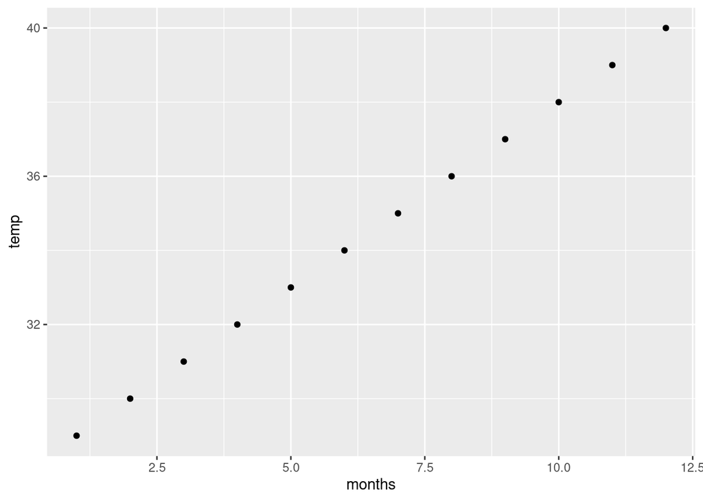

```r
qplot(x = months, y = temp)
```

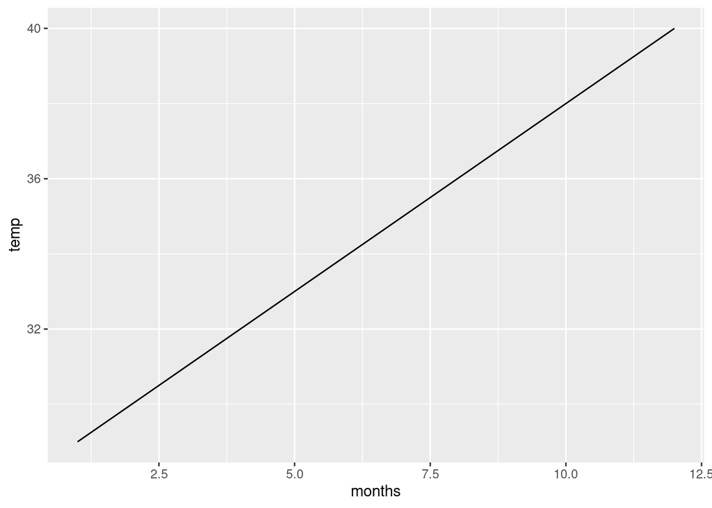

```r
ggplot(data.frame(months,temp), aes(x = months, y = temp)) + geom_line()
```

**Exercise**

Create a vector from 0 to 100 with stepsize 1, and call it a. Create a second vector b, which is the logarithm of vector a.

Create a plot of vector a and b, by using the package ggplot2.

**Solution**

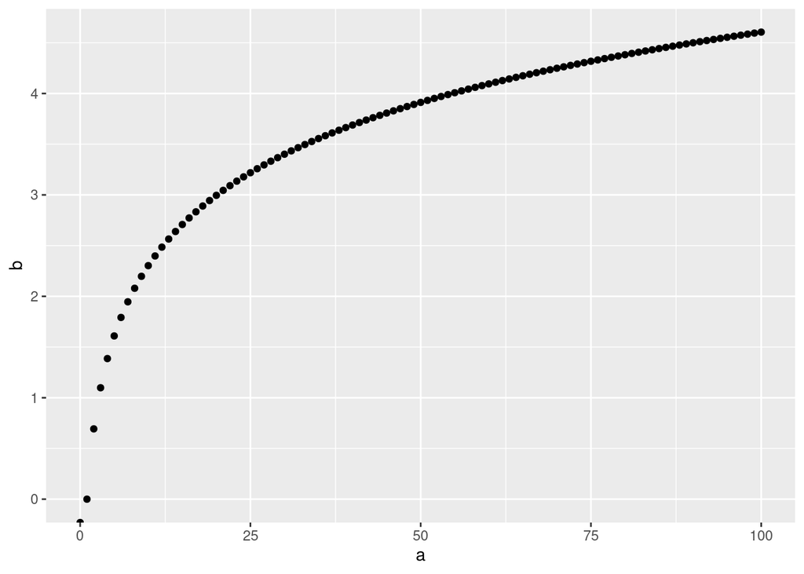

```r
library(ggplot2)

a <- seq(from=0, to=100, by=1)
b <- log(a)

qplot(x = a, y = b)
```

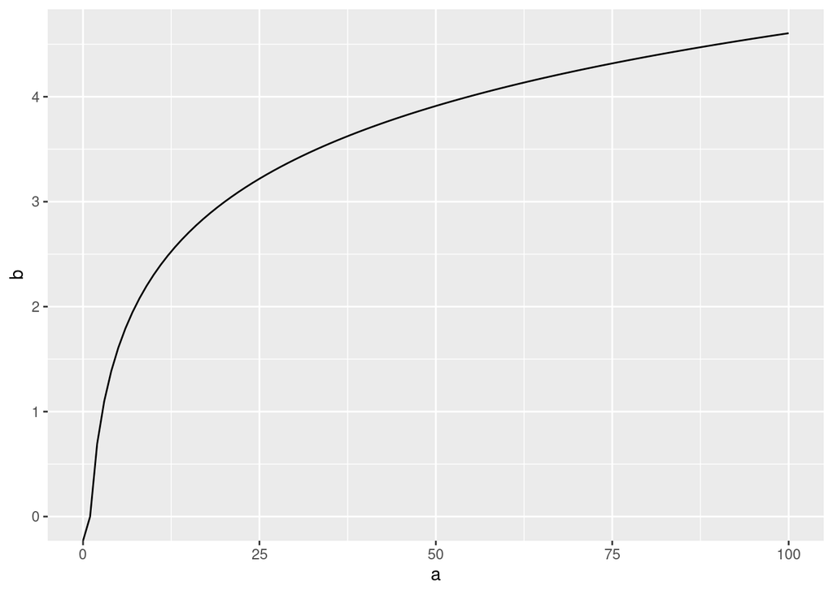

```r
ggplot(data.frame(a, b), aes(x = a, y = b)) +
  geom_line()
```

## Checkpoint 1.3

**Exercise**

Create a vector A which is a sequence from 0 to $2 * \pi$ with step size 0.01. Create a vector B which is the tangens of A.

Plot A and B.

**Solution**

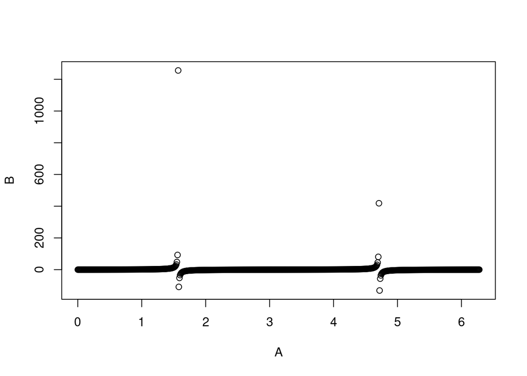

```r
A<-seq(from = 0, to = 2*pi, by = 0.01)
B<- tan(A) #cos(A)
plot(A,B)
```

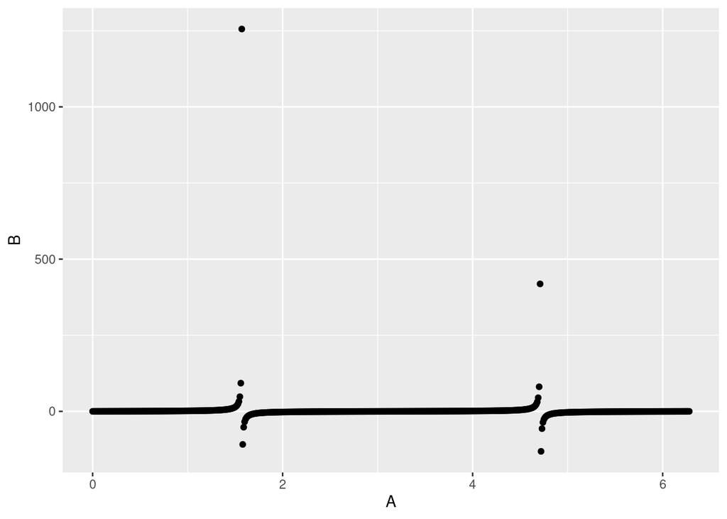

```r
qplot(x = A, y = B) #quickplot
```

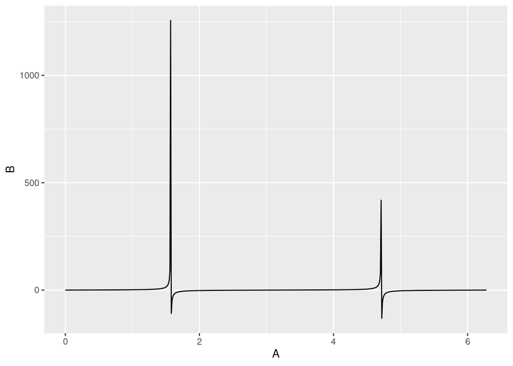

```r
ggplot(data.frame(A, B), aes(x = A, y = B)) + geom_line()
```

**Exercise**

Plot a cos graph. Create appropriate data to so so and plot it.

**Solution**

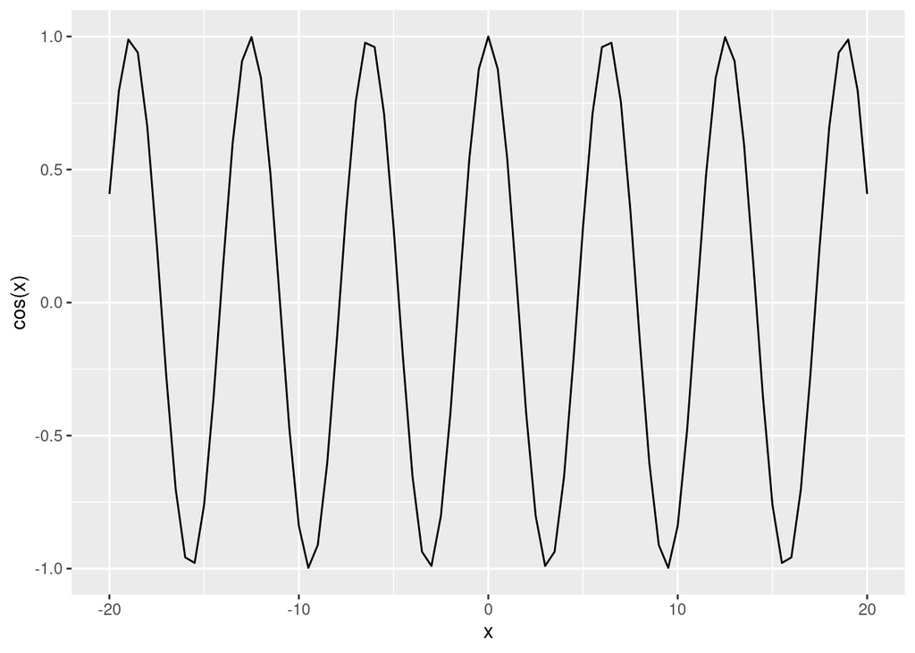

```r
x <- seq(from = -20, to = 20, by = 0.5)
qplot(x = x, y = cos(x), geom = "line")
```

**Exercise**

Plot a histogram with random numbers between 1 and 1000. Create appropriate data to so so and plot it.

**Solution**

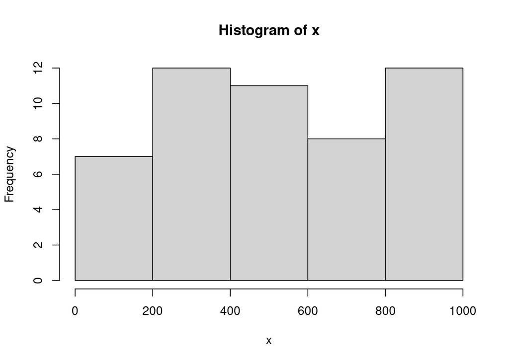

```r
x <- sample(1:1000, 50)
hist(x)
```

# Repetition of Module 2

## Checkpoint 2.1

**Exercise**

Choose any plot you like and start playing around. Change colours, points, titles, etc. Use the internet or any other help function you wish.

Use the table `wdata` for this.

```r
set.seed(1234)
wdata = data.frame(
        gender = factor(rep(c("F", "M", "D"), each=200)),
        weight = c(rnorm(200, 55), rnorm(200, 58), c(rnorm(100, 55), rnorm(100, 58))))
head(wdata)
```

```
  gender   weight
1      F 53.79293
2      F 55.27743
3      F 56.08444
4      F 52.65430
5      F 55.42912
6      F 55.50606
```

**Solution**

Note that in order to run the below code, you need to install and load the `viridis` package :

```r
# install.packages("viridis")
library(viridis)
```

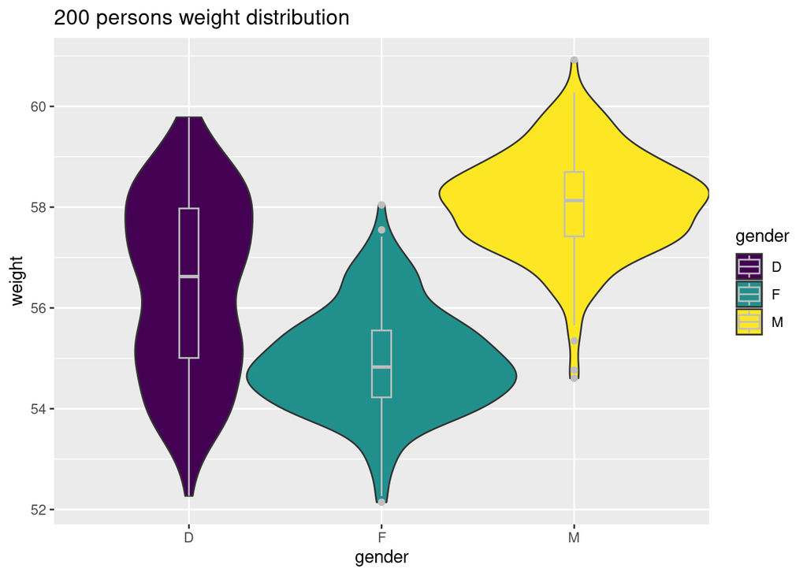

```r
library(ggplot2)
# Combine violin and boxplot. Change colour of Boxplot and make it smaler then violin plot. Choose a colour scheme.
ggplot(data = wdata, aes(x = gender, y = weight, fill = gender)) +
  geom_violin(width = 1.4) +
  geom_boxplot(width = 0.1, color="grey") +
  scale_fill_viridis(discrete = TRUE) +
  ggtitle("200 persons weight distribution")
```

**Exercise**

Under Solution, you find a sequence of code to create a histogram. Follow this code and try to find out what the individual commands do.

**Solution**

In order to run the below code, you need to install the below package.

```r
install.packages("viridis")
```

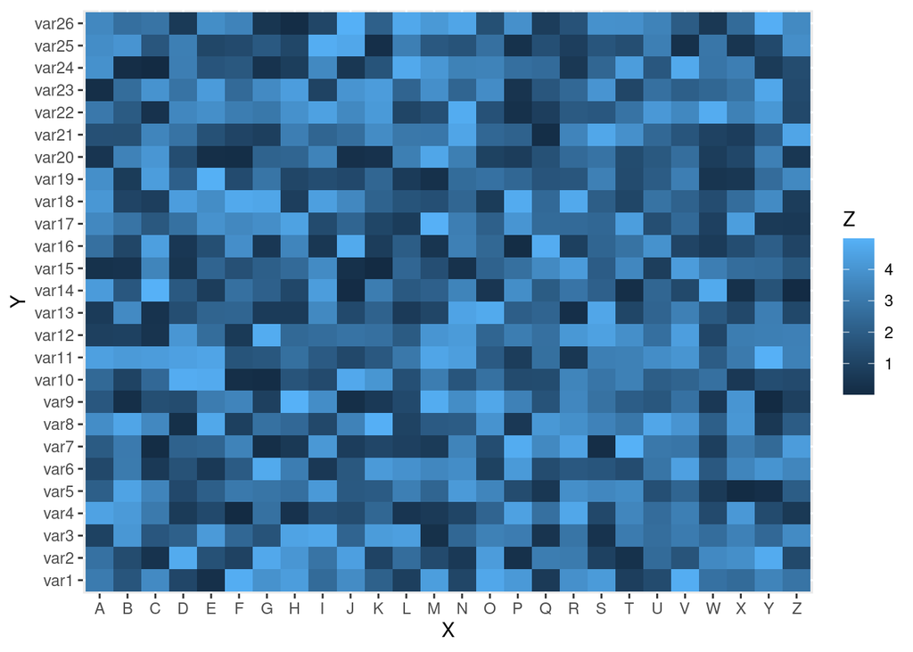

```r
#### Create Heatmap
# Library
library(ggplot2)

# Dummy data
# Library
library(ggplot2)

# Dummy data
x <- LETTERS[1:26]
y <- paste0("var", seq(1,26))
data <- expand.grid(X=x, Y=y)
data$Z <- runif(676, 0, 5)

# Heatmap
ggplot(data, aes(X, Y, fill= Z)) +
  geom_tile()
```

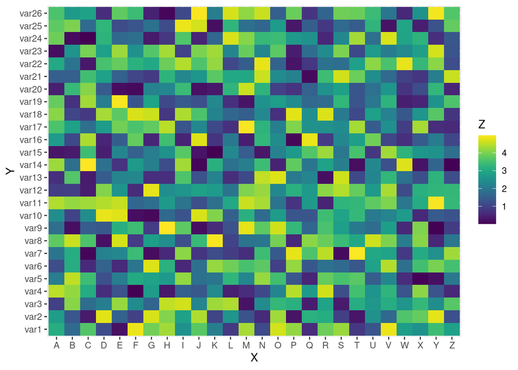

```r
# change colour
library(viridis)
ggplot(data, aes(X, Y, fill= Z)) +
  geom_tile() +
  scale_fill_viridis(discrete=FALSE)
```

**Exercise**

visualize the relation between transmission type and mpg (mtcars data)

**Hint**

load the `mtcars` data :

```r
data(mtcars)
```

**Solution**

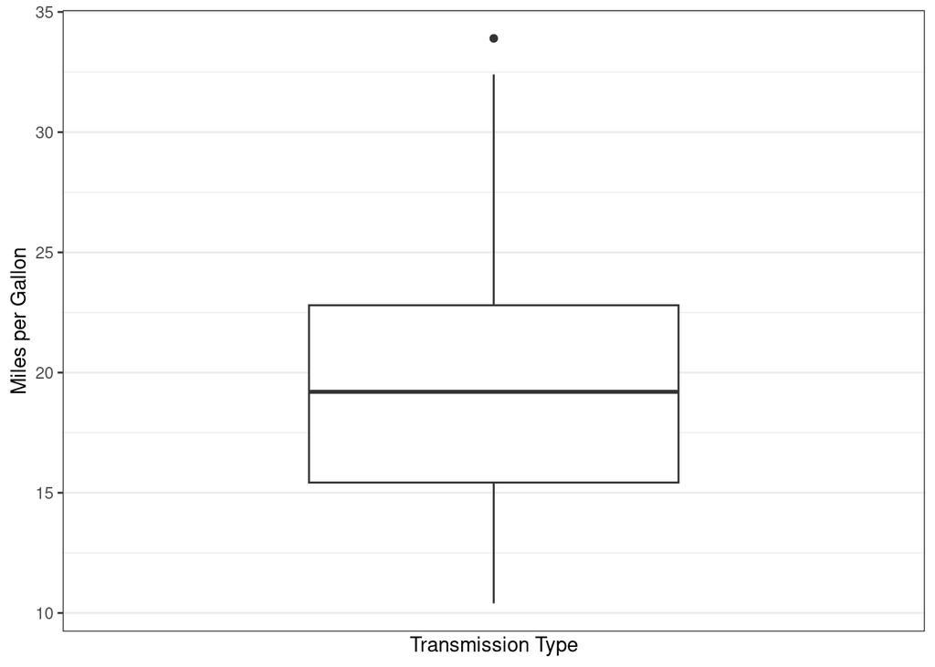

```r
ggplot(mtcars, aes (x = am, y = mpg))+
  geom_boxplot() +
  scale_x_discrete(labels = c("Automatic", "Manual"))+
  labs (x = "Transmission Type", y = "Miles per Gallon") + theme_bw()
```

**Exercise**

construct a basic ridgeline plot with the Orange data frame. The `Orange` dataset is provided with the `ggridges` package. Install the package, and load the `Orange` dataset after.

**Hint**

```r
install.packages("ggridges")
data(Orange)
```

**Solution**

```r
# Libraries
# install.packages("ggridges")
library(ggridges)
library(ggplot2)

# Creating the ridgeline plot
head(Orange)
```

```
  Tree  age circumference
1    1  118            30
2    1  484            58
3    1  664            87
4    1 1004           115
5    1 1231           120
6    1 1372           142
```

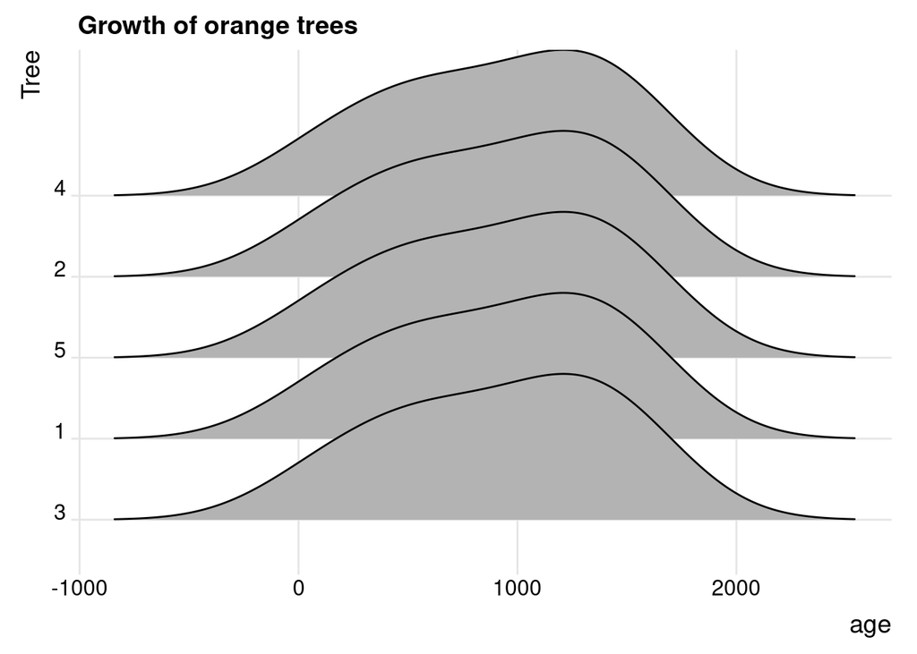

```r
ggplot(Orange, aes(x = age, y = Tree, fill = circumference)) +
  geom_density_ridges() +
  theme_ridges() +
  theme(legend.position = "none") +
  labs(title = "Growth of orange trees")
```

**Exercise (Advanced)**

Note that for this exercise, you need to go to the Biodiversity Exploratories database BExIS and download a specific dataset.

create a soil texture triangle from the dataset 14686 of the BE.

Creating the texture classes triangle using ggtern

**Solution**

```r
# install.packages("readxl")
library(readxl)
soil_texture <- read_excel("C:/Users/Downloads/Copy of 14686_10_data.xlsx",
                           sheet = "Data")
head(soil_texture)


# Creating subset from soil_texture
data_points <- subset(soil_texture, Type == "G", select = c(EP_Plotid, Exploratory, Clay...12, Silt, Sand))
head(data_points)

# Changing column names
colnames(data_points)[colnames(data_points) == "Clay...12"] <- "Clay"
head(data_points)

# Creating ternary plot
library("ggtern")
library("scales")
ggtern(data=data_points, aes(x = Clay, y = Silt, z = Sand, color = Clay, shape = Exploratory)) +
  scale_color_gradient(high = "red", low = "blue") +
  labs(title = "Soil texture triangle") +
  facet_grid(. ~ Exploratory) +
  geom_point()
```

**Exercise**

Create a boxplot of the “mpg” variable across the “cyl” variable using the dataset mtcars.

**Solution**

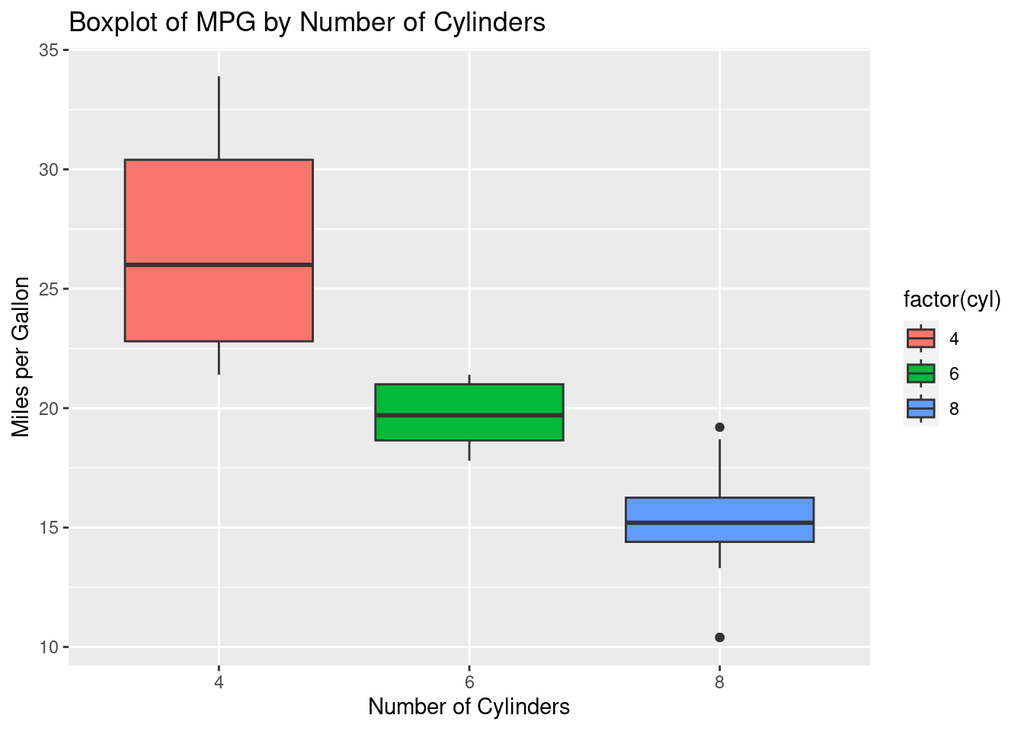

```r
# Load necessary library
library(ggplot2)

# Load mtcars dataset
data(mtcars)

# Create a boxplot
ggplot(data = mtcars, aes(x = factor(cyl), y = mpg, fill= factor(cyl))) +
  geom_boxplot() +
  labs(title = "Boxplot of MPG by Number of Cylinders",
       x = "Number of Cylinders",
       y = "Miles per Gallon")
```

## Checkpoint 2.2

**Exercise**

Visualize the distribution of the categorial variable species of the `iris` dataset in a faceted plot. Show the relation of sepal length and width

**Solution**

```r
view(iris)
?iris
```

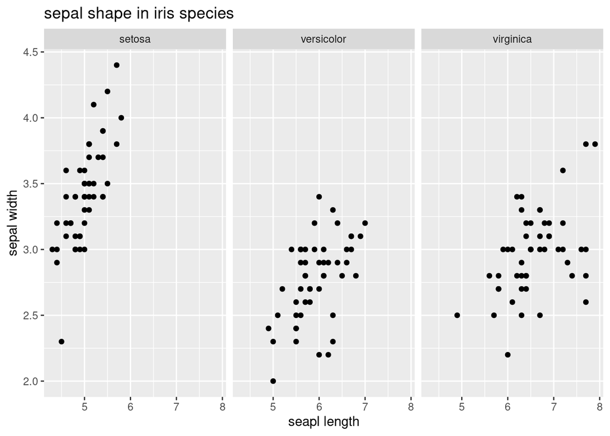

```r
ggplot(iris, aes(x = Sepal.Length, y = Sepal.Width)) +
  geom_point() +
  facet_wrap(~Species) +
  labs(title = "sepal shape in iris species",
       x = "seapl length",
       y = "sepal width")
```

**Exercise**

Create a scatter plot showing the relationship between tree height and tree volume using the “trees” dataset and add a line.

**Solution**

```r
data("trees")

?trees
```

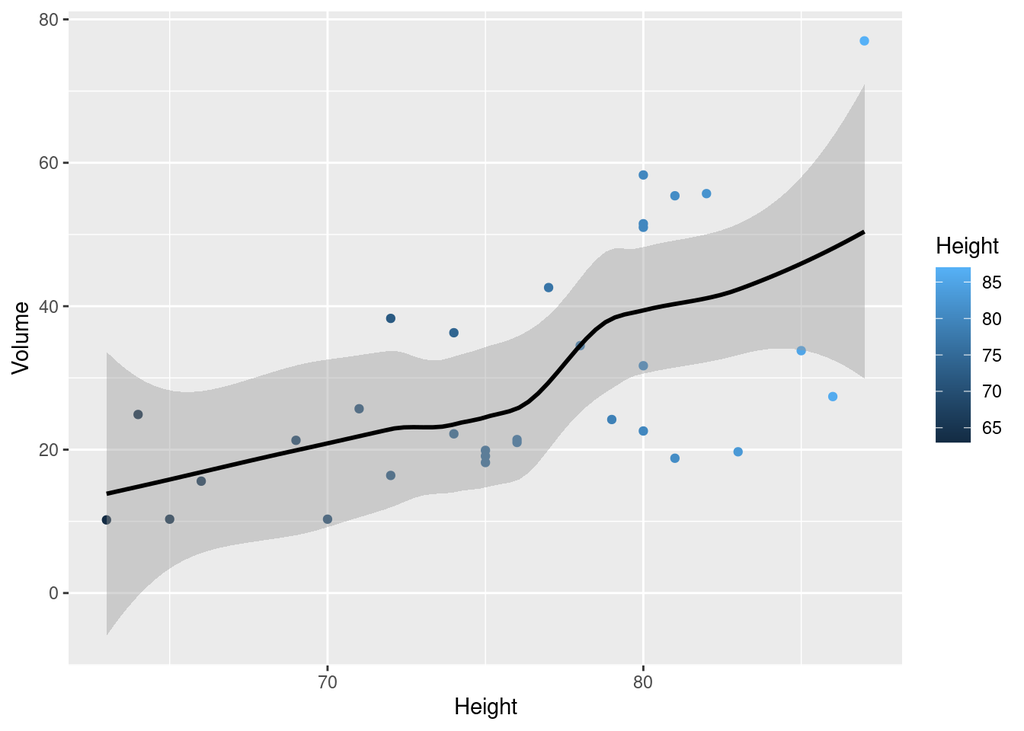

```r
ggplot(trees, aes(x = Height, y=Volume)) +
geom_point(aes(color=Height)) + geom_smooth(color="black")
```

**Exercise**

Work with the iris dataset. Visualise the relationship between the sepal width and petal length in addition to see if it is influenced by species

**Solution**

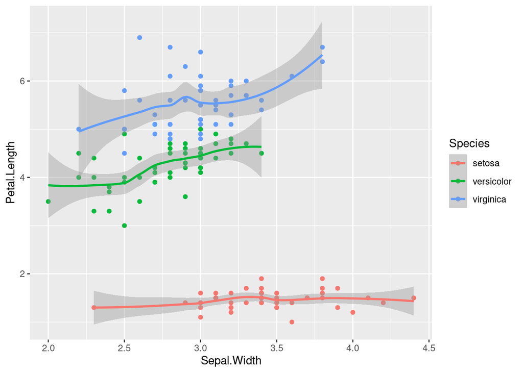

```r
iris %>%
ggplot ( aes (x = Sepal.Width, y = Petal.Length, color = Species) )+
geom_point()+
geom_smooth()
```

### Exercise

Create a density plot of the bill length of each species of penguins, using colorblind safe. Save the image as jpeg

### Solution

```r
install.packages("palmerpenguins")
install.packages("ggthemes")
```

```r
library(tidyverse)
library(palmerpenguins)
library(ggthemes)
data(penguins)
glimpse(penguins)
```

```
Rows: 344
Columns: 8
$ species           <fct> Adelie, Adelie, Adelie, Adelie, Adelie, Adelie, Adel…
$ island            <fct> Torgersen, Torgersen, Torgersen, Torgersen, Torgerse…
$ bill_length_mm    <dbl> 39.1, 39.5, 40.3, NA, 36.7, 39.3, 38.9, 39.2, 34.1, …
$ bill_depth_mm     <dbl> 18.7, 17.4, 18.0, NA, 19.3, 20.6, 17.8, 19.6, 18.1, …
$ flipper_length_mm <int> 181, 186, 195, NA, 193, 190, 181, 195, 193, 190, 186…
$ body_mass_g       <int> 3750, 3800, 3250, NA, 3450, 3650, 3625, 4675, 3475, …
$ sex               <fct> male, female, female, NA, female, male, female, male…
$ year              <int> 2007, 2007, 2007, 2007, 2007, 2007, 2007, 2007, 2007…
```

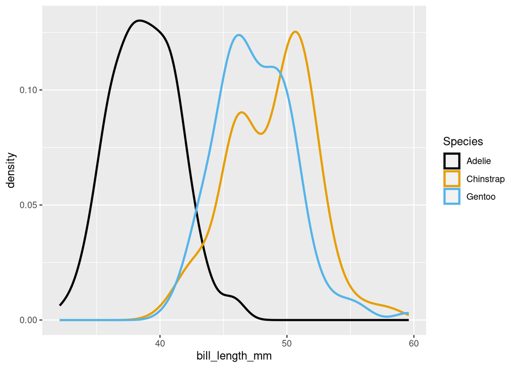

```r
ggplot(penguins, aes(x = bill_length_mm, color = species)) +
  geom_density(size = 1) +
  labs(color = "Species") +
  scale_color_colorblind()
```

```r
ggsave(filename = "Bill_length.jpeg")
```

**Exercise**

Create a scatterplot of bill length vs body mass of the penguin dataset, differentiating species by color and island by shape. Add a trendline without confidence interval.

**Solution**

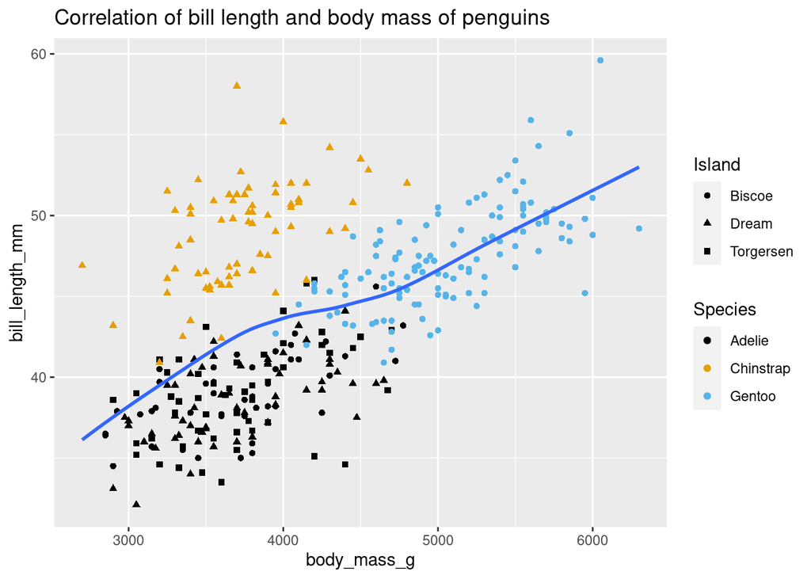

```r
ggplot(penguins, aes(x = body_mass_g, y = bill_length_mm)) +
  geom_point(aes(color = species, shape = island)) +
  geom_smooth(se = FALSE) +
  labs(title = "Correlation of bill length and body mass of penguins", color = "Species", shape = "Island") +
  scale_color_colorblind()
```

**Exercise**

From the penguin dataset, create a boxplot of species.

**Solution**

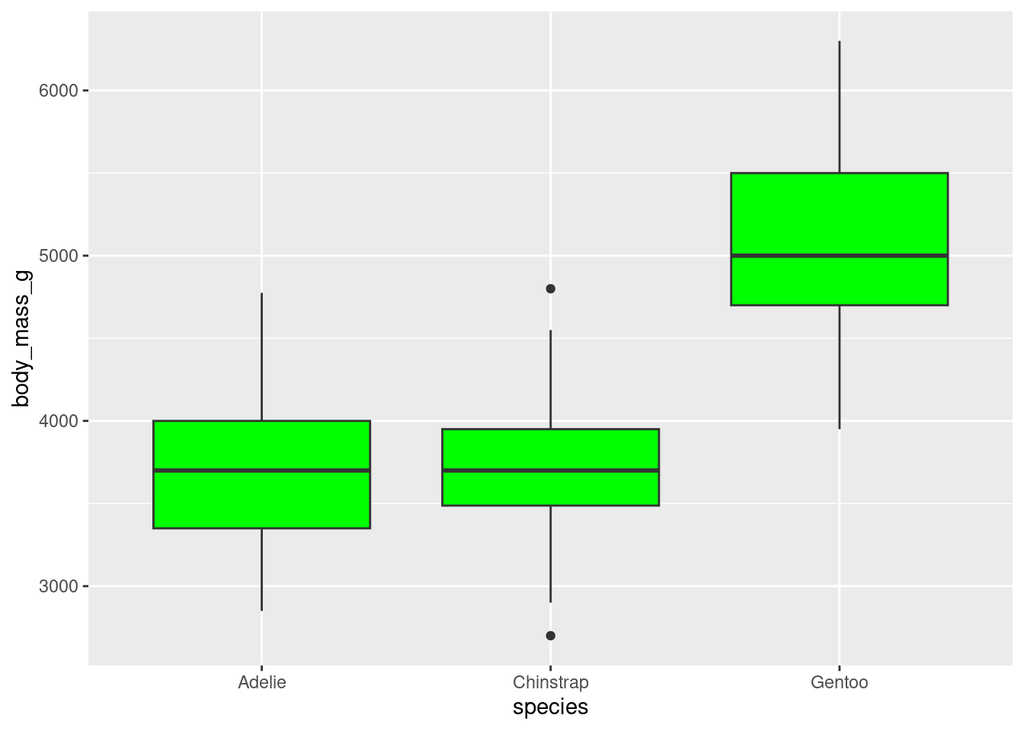

```r
ggplot(penguins, aes(x = species, y = body_mass_g)) +
  geom_boxplot(fill = "green")
```

## Checkpoint 2.3

**Exercise**

What about the difference between na and NA? Is there any? Try the same exercise as above, but replace any number with „na“.

*Note* this question is abou the data reading exercises in Module 2, where you changed some values of a dataset to e.g. NA, and tested what happens in the read function.

**Solution**

Interesting. Excel reads it as the same. But R makes a difference and doesn’t recognize na as actual missing values (like NA).

**Exercise**

Import the dataset gardens.csv from the Beckerman book using read.csv and setting the working directory as the datasets folder

**Solution**

```r
library(readr)

getwd()
setwd("C:/Users/Desktop/OneDrive - TUM/PhD/R_programming/Datasets/") # note this path is slightly changed to not show the name of the person writing the exercise
gardens <- read.csv("gardens.csv")

# Exercise: Import the dataset biomass.loss.csv with read_csv
biomass_loss <- read_csv("biomass.loss.csv")
```

**Exercise**

Import the dataset biomass.loss.csv from the Beckerman book with read_csv

**Solution**

```r
biomass_loss <- read_csv("biomass.loss.csv")
```

## Checkpoint 2.4 (Additional)

**Exercise**

Load the mtcars mtcars and tweak the following code to run smoothely

```r
mtcars
?mtcars
libray(gglot)

ggplot(mtcas, aes(x=(hp), y=mpg))+
  geom_point()+geonm_smoooth("")
```

**Solution**

```r
mtcars
```

```
                     mpg cyl  disp  hp drat    wt  qsec vs am gear carb
Mazda RX4           21.0   6 160.0 110 3.90 2.620 16.46  0  1    4    4
Mazda RX4 Wag       21.0   6 160.0 110 3.90 2.875 17.02  0  1    4    4
Datsun 710          22.8   4 108.0  93 3.85 2.320 18.61  1  1    4    1
Hornet 4 Drive      21.4   6 258.0 110 3.08 3.215 19.44  1  0    3    1
Hornet Sportabout   18.7   8 360.0 175 3.15 3.440 17.02  0  0    3    2
Valiant             18.1   6 225.0 105 2.76 3.460 20.22  1  0    3    1
Duster 360          14.3   8 360.0 245 3.21 3.570 15.84  0  0    3    4
Merc 240D           24.4   4 146.7  62 3.69 3.190 20.00  1  0    4    2
Merc 230            22.8   4 140.8  95 3.92 3.150 22.90  1  0    4    2
Merc 280            19.2   6 167.6 123 3.92 3.440 18.30  1  0    4    4
Merc 280C           17.8   6 167.6 123 3.92 3.440 18.90  1  0    4    4
Merc 450SE          16.4   8 275.8 180 3.07 4.070 17.40  0  0    3    3
Merc 450SL          17.3   8 275.8 180 3.07 3.730 17.60  0  0    3    3
Merc 450SLC         15.2   8 275.8 180 3.07 3.780 18.00  0  0    3    3
Cadillac Fleetwood  10.4   8 472.0 205 2.93 5.250 17.98  0  0    3    4
Lincoln Continental 10.4   8 460.0 215 3.00 5.424 17.82  0  0    3    4
Chrysler Imperial   14.7   8 440.0 230 3.23 5.345 17.42  0  0    3    4
Fiat 128            32.4   4  78.7  66 4.08 2.200 19.47  1  1    4    1
Honda Civic         30.4   4  75.7  52 4.93 1.615 18.52  1  1    4    2
Toyota Corolla      33.9   4  71.1  65 4.22 1.835 19.90  1  1    4    1
Toyota Corona       21.5   4 120.1  97 3.70 2.465 20.01  1  0    3    1
Dodge Challenger    15.5   8 318.0 150 2.76 3.520 16.87  0  0    3    2
AMC Javelin         15.2   8 304.0 150 3.15 3.435 17.30  0  0    3    2
Camaro Z28          13.3   8 350.0 245 3.73 3.840 15.41  0  0    3    4
Pontiac Firebird    19.2   8 400.0 175 3.08 3.845 17.05  0  0    3    2
Fiat X1-9           27.3   4  79.0  66 4.08 1.935 18.90  1  1    4    1
Porsche 914-2       26.0   4 120.3  91 4.43 2.140 16.70  0  1    5    2
Lotus Europa        30.4   4  95.1 113 3.77 1.513 16.90  1  1    5    2
Ford Pantera L      15.8   8 351.0 264 4.22 3.170 14.50  0  1    5    4
Ferrari Dino        19.7   6 145.0 175 3.62 2.770 15.50  0  1    5    6
Maserati Bora       15.0   8 301.0 335 3.54 3.570 14.60  0  1    5    8
Volvo 142E          21.4   4 121.0 109 4.11 2.780 18.60  1  1    4    2
```

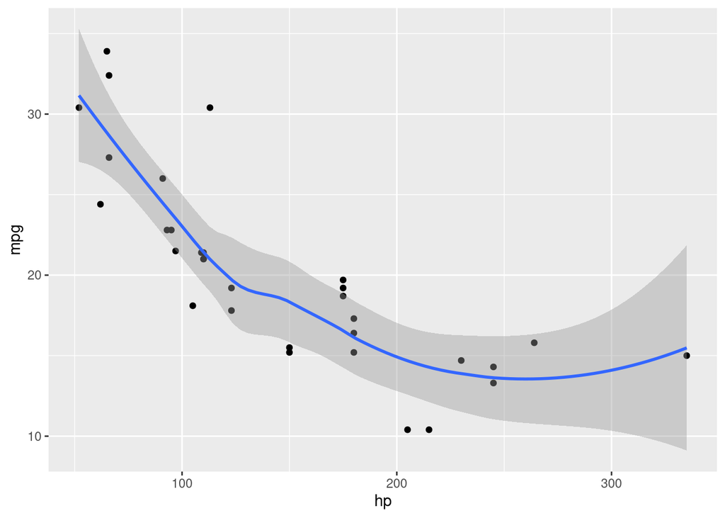

```r
?mtcars
library(ggplot2)

ggplot(mtcars, aes(x=hp, y=mpg))+
  geom_point()+geom_smooth()
```

**Exercise**

saving a plot as a pdf : Create a plot (any plot you like) and save it as pdf.

**Solution**

```r
my_scatter_plot <- ggplot(mpg, aes(x = cty, y = hwy)) + geom_point()

ggsave(filename = "mpg-plot.pdf", plot = my_scatter_plot)
```

**Exercise**

edit the following code for it to work

```r
mpg

ggplot (aes (x = "displ" y = hwy) +

geom_point (color = class)+

geom_smooth ()
```